[Holger Sennhenn-Reulen](https://www.holgersennhennreulen.github.io/)

Applied statistician @ [Northwest German Forest Research Station](https://www.nw-fva.de)

Contact: holger dot sennhenn at nw-fva.de

# Example Data: Mortality

November 13, 2019

This document shows the steps I’ve done in order to come to mortality data we can use for statistical modeling.

This data is *openly available* as repository to the following publication (sorry for incorrect typeface of Polish letters):

> B. Brzeziecki, K. Bielak, L. Bolibok, S. Drozdowski, J. Zajaczkowski, H. Zybura (2019): Structural and compositional dynamics of strictly protected woodland communities with silvicultural implications, using Bialowieza Forest as an example. Annals of Forest Science 75(3).

Here is the [link](https://ist.blogs.inra.fr/afs/2018/10/17/structural-and-compositional-dynamics-of-strictly-protected-woodland-communities-with-silvicultural-implications-using-bialowieza-forest-as-an-example/) to blog post where you can find links to the published manuscript and also to the data repository.

# 1 Organise R Session

```r
library("plyr")
library("ggplot2")
rm(list = ls())
```

# 2 Load data

Prior to loading the data, I saved the respective spreadsheets into separate csv-files:

```r
dl <- read.csv("LIVE_TREES.csv", dec = ",")
di <- read.csv("INGROWTH_TREES.csv", dec = ",")
do <- read.csv("OUTGROWTH_TREES.csv", dec = ",")
```

Let’s have a look on the structure of those datasets:

```r
str(dl)
```

```
'data.frame':   12299 obs. of  8 variables:
 $ Community     : int  1 1 1 1 1 1 1 1 1 1 ...
 $ Plot          : int  3 3 3 3 3 3 3 3 3 3 ...
 $ Patch         : int  6 6 6 6 6 6 6 6 6 6 ...
 $ Census        : int  1 1 1 1 1 1 1 1 1 1 ...
 $ Species       : int  1 1 1 1 1 1 1 1 2 2 ...
 $ DbhClassBottom: int  50 100 150 200 250 300 350 400 50 100 ...
 $ Trees         : int  4 16 19 22 14 5 6 2 34 69 ...
 $ BasalArea     : num  0.0245 0.2028 0.4593 0.8635 0.7942 ...
```

```r
str(di)
```

```
'data.frame':   1262 obs. of  8 variables:
 $ Community     : int  1 1 1 1 1 1 1 1 1 1 ...
 $ Plot          : int  3 3 3 3 3 3 3 3 3 3 ...
 $ Patch         : int  6 6 6 6 6 6 6 6 6 6 ...
 $ Census        : int  1 1 1 1 2 2 2 2 2 3 ...
 $ Species       : int  2 2 4 4 2 4 4 5 5 2 ...
 $ DbhClassBottom: int  50 100 50 100 50 50 100 50 100 50 ...
 $ Trees         : int  2 1 35 2 6 19 2 7 2 1 ...
 $ BasalArea     : num  0.00635 0.0141 0.12945 0.01651 0.02155 ...
```

```r
str(do)
```

```
'data.frame':   4311 obs. of  8 variables:
 $ Community     : int  1 1 1 1 1 1 1 1 1 1 ...
 $ Plot          : int  3 3 3 3 3 3 3 3 3 3 ...
 $ Patch         : int  6 6 6 6 6 6 6 6 6 6 ...
 $ Census        : int  1 1 1 1 1 1 1 1 1 1 ...
 $ Species       : int  1 1 1 1 1 2 2 2 2 2 ...
 $ DbhClassBottom: int  50 100 150 200 250 50 100 150 200 250 ...
 $ Trees         : int  2 2 1 1 1 21 27 10 4 3 ...
 $ BasalArea     : num  0.0138 0.0227 0.023 0.046 0.0507 ...
```

From the Readme-file in the data-repository, we get valuable information on how to link the three different datasets:

> The exact meaning of given census number differs between tables. In the case of LIVE_TREES table, census number indicates measurement year (1 for 1936, 2 for 1957, a so on to 7 for 2012). In the case of INGROWTH_TREES table, census #N indicates period between censuses N and N+1, during which trees from particular dbh class have reached or passed dbh threshold value for the first time. In other words, the census #N points to trees that were counted for the first time on N+1 census. Census number range in this table is 1-6. In the case of OUTGROWTH_TREES table, census #N stands for period between censuses N and N+1, as well, but it should be read as the last census in which the tree had been alive, before it was found dead in N+1 census. Census number range in this table is 1-6, as well.

Let’s have a check:

## 2.1 Do numbers match?

```r
sdfl <- subset(dl, Community == 1 & Plot == 3 & Patch == 6 &
                 Species == 2)[, c("Census", "DbhClassBottom", "Trees")]
sdfi <- subset(di, Community == 1 & Plot == 3 & Patch == 6 &
                 Species == 2)[, c("Census", "DbhClassBottom", "Trees")]
sdfo <- subset(do, Community == 1 & Plot == 3 & Patch == 6 &
                 Species == 2)[, c("Census", "DbhClassBottom", "Trees")]
ddl <- ddply(sdfl, c("Census"), summarise, n = sum(Trees))
ddi <- ddply(sdfi, c("Census"), summarise, n = sum(Trees))
ddo <- ddply(sdfo, c("Census"), summarise, n = sum(Trees))
ddl
```

```
  Census   n
1      1 186
2      2 123
3      3 100
4      4  77
5      5  59
6      6  51
7      7  40
```

```r
diff(ddl$n)
```

```
[1] -63 -23 -23 -18  -8 -11
```

```r
ddi
```

```
  Census n
1      1 3
2      2 6
3      3 1
4      5 2
5      6 1
```

```r
ddo
```

```
  Census  n
1      1 66
2      2 29
3      3 24
4      4 18
5      5 10
6      6 12
```

# 3 Merge live-tree and outgrowth-tree data

```r
## Caution: The next two commands take a loooong time.
ddl <- ddply(dl, c("Census", "Community", "Plot", "Patch", "Species", "DbhClassBottom"),
              summarise, .drop = FALSE,
              n = sum(Trees))
ddo <- ddply(do, c("Census", "Community", "Plot", "Patch", "Species", "DbhClassBottom"),
              summarise, .drop = FALSE,
              n = sum(Trees))
ddl$key <- paste(ddl$Census, ddl$Community, ddl$Plot, ddl$Patch,
                 ddl$Species, ddl$DbhClassBottom, sep = "_")
ddo$key <- paste(ddo$Census, ddo$Community, ddo$Plot, ddo$Patch,
                 ddo$Species, ddo$DbhClassBottom, sep = "_")
```

```r
dd <- merge(ddl, ddo, by = "key")
rm(ddl, ddo)
```

```r
dd <- dd[dd$n.x > 0.5, ]
dd <- data.frame(Census = dd$Census.x,
                 Community = dd$Community.x,
                 Plot = dd$Plot.x,
                 Patch = dd$Patch.x,
                 Species = dd$Species.x,
                 DbhClassBottom = dd$DbhClassBottom.x,
                 n_all = dd$n.x,
                 n_dead = dd$n.y)
d <- dd
rm(dd)
d$key <- paste(d$Census, d$Community, d$Plot, d$Patch, d$Species, d$DbhClassBottom, sep = "_")
d$group_id <- paste(d$Community, d$Plot, d$Patch, d$Species, d$DbhClassBottom, sep = "_")
d$group_id_coarse <- paste(d$Community, d$Plot, d$Patch, d$Species, sep = "_")
```

# 4 Final data

```r
head(d)
```

```
  Census Community Plot Patch Species DbhClassBottom n_all n_dead
1      1         1    3     6       1            100    16      2
2      1         1    3     6       1            150    19      1
3      1         1    3     6       1            200    22      1
4      1         1    3     6       1            250    14      1
5      1         1    3     6       1            300     5      0
6      1         1    3     6       1            350     6      0
            key    group_id group_id_coarse
1 1_1_3_6_1_100 1_3_6_1_100         1_3_6_1
2 1_1_3_6_1_150 1_3_6_1_150         1_3_6_1
3 1_1_3_6_1_200 1_3_6_1_200         1_3_6_1
4 1_1_3_6_1_250 1_3_6_1_250         1_3_6_1
5 1_1_3_6_1_300 1_3_6_1_300         1_3_6_1
6 1_1_3_6_1_350 1_3_6_1_350         1_3_6_1
```

```r
write.csv(d, file = "d_mortality.csv")
```

## 4.1 Some illustrations

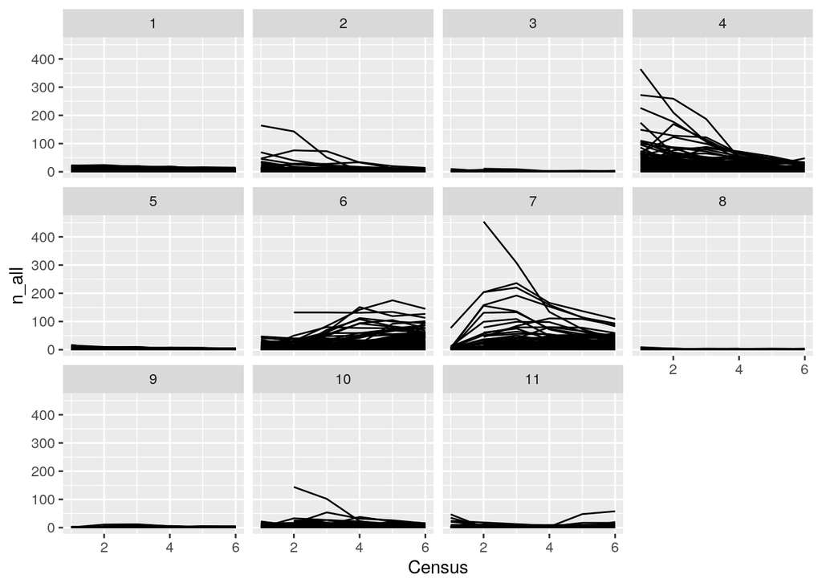

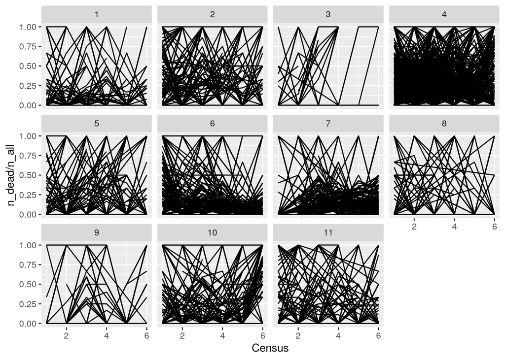

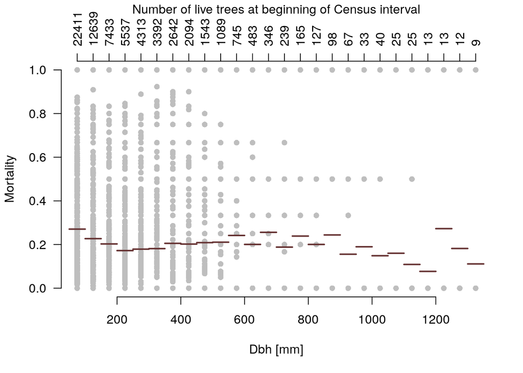

```r
dd <- ddply(d, c("DbhClassBottom"), summarise,
            mm = mean(n_dead/n_all),
            n = sum(n_all))
plot(d$DbhClassBottom + 25, d$n_dead/d$n_all, pch = 16, col = "grey",
     las = 1, ylab = "Mortality", xlab = "Dbh [mm]", bty = "n")
for (i in 1:nrow(dd)) {
  lines(dd$DbhClassBottom[i] + c(0, 50),
         rep(dd$mm[i], 2),
         col = rgb(0.4, 0.2, 0.2), lwd = 2)
}
axis(3, at = dd$DbhClassBottom + 25, lab = dd$n, las = 2)
mtext(side = 3, text = "Number of live trees at beginning of Census interval", line = 3)
```

We see a higher mortality in trees with very low and higher physical age, ie. dbh.

How can we model this adequately? We will answer this question later during this course.